# 204.2. The Monster reference catalog

For the Rubin Science Platform at data.lsst.cloud.  
Data Release: [Data Preview 1](https://dp1.lsst.io)  
Container Size: large  
LSST Science Pipelines version: r29.2.0  
Last verified to run: 2025-09-17  
Repository: github.com/lsst/tutorial-notebooks

**Learning objective:** To learn about "The Monster" reference catalog.

**LSST data products:** `the_monster_20250219`.

**Packages:** `numpy`, `matplotlib`, `scipy`, `astropy`, `lsst.geom`, `lsst.daf.butler`, `lsst.rsp`, `lsst.rsp.get_tap_service`, `lsst.rsp.retrieve_query`.

**Credit:** Originally developed by Andrés A. Plazas Malagón and the Rubin Community Science team. Please consider acknowledging them if this notebook is used for the preparation of journal articles, software releases, or other notebooks.

**Get Support:** Everyone is encouraged to ask questions or raise issues in the [Support Category](https://community.lsst.org/c/support) of the Rubin Community Forum. Rubin staff will respond to all questions posted there.

## 1. Introduction

To support the photometric and astrometric calibration of early data from the Vera C. Rubin Observatory, a new all-sky reference catalog called *The Monster* has been developed. This catalog provides synthetic fluxes in the LSST **ugrizy** bandpasses, constructed by combining and transforming data from a prioritized list of external reference catalogs.

*The Monster* is designed to meet the demanding calibration requirements of the LSST, ensuring high source density ($>$10 reference stars per `NSIDE`=256 HEALPix pixel) and full-sky coverage for all bands. It includes astrometry based on [Gaia DR3](https://ui.adsabs.harvard.edu/abs/2023A&A...674A...1G/abstract), and photometry transformed into LSST-native bandpasses, minimizing the need for additional color transformations during image processing.

The catalog is organized using [Hierarchical Triangular Mesh](https://www.skyserver.org/htm/) (HTM) level-7 trixels, a spatial indexing system that divides the celestial sphere into approximately 1.5 million small triangular regions, each covering about 0.05 square degrees—roughly the footprint of a single LSSTCam CCD. This hierarchical scheme enables efficient data access: rather than querying the entire sky, users can retrieve only the relevant subset of the catalog corresponding to their region of interest. This structure supports scalable and fast photometric and astrometric calibrations across the sky during Rubin operations.

**References**:

- [DMTN-277: The Monster: A reference catalog with synthetic ugrizy-band fluxes for the Vera C. Rubin observatory](https://dmtn-277.lsst.io/)
- See notebooks folder in the GitHub repository associated with DMTN-277, [github.com/lsst-dm/dmtn-277](https://github.com/lsst-dm/dmtn-277/), for further examples.

**Related tutorials:** See other DP1 200-level calibration tutorials.

### 1.1. Import packages

Import `numpy`, a fundamental package for scientific computing with arrays in Python (numpy.org), and `matplotlib`, a comprehensive library for data visualization ([matplotlib.org](https://matplotlib.org/); [matplotlib gallery](https://matplotlib.org/stable/gallery/index.html)).

From the `lsst` package, import modules for accessing the butler and geometry utilities from the LSST Science Pipelines ([pipelines.lsst.io](https://pipelines.lsst.io/)).

From `astropy`, import modules for celestial coordinate transformations, units, and tables  
([astropy.org](https://www.astropy.org/)).

From `lsst.meas.algorithms` get `ReferenceObjectLoader` to retrieve *the Monster* and account for proper motions.

```python
import numpy as np
import matplotlib.pyplot as plt
from astropy.coordinates import SkyCoord
import astropy.units as u
from astropy.time import Time

import lsst.geom
import lsst.daf.butler as dafButler
from lsst.meas.algorithms import ReferenceObjectLoader
from lsst.rsp import get_tap_service
```

### 1.2. Define parameters and functions

Instantiate the butler.

```python
butler = dafButler.Butler("dp1", collections="LSSTComCam/DP1")
assert butler is not None
```

Create an instance of the Table Access Protocol (TAP) service, and assert that it exists.

```python
rsp_tap = get_tap_service("tap")
assert rsp_tap is not None
```

## 2. Access

Define a particular location on the sky. Use the center of the Extended Chandra Deep Field South, in degrees.

```python
ra_cen, dec_cen = 53.13, -28.10
```

Get the tract correspoding to the coordinates.

```python
my_spherePoint = lsst.geom.SpherePoint(ra_cen*lsst.geom.degrees,
                                       dec_cen*lsst.geom.degrees)
skymap = butler.get('skyMap')
tract = skymap.findTract(my_spherePoint)
my_tract = tract.tract_id
print('my_tract: ', my_tract)
```

```
my_tract:  5063
```

Get the name of "The Monster" catalog in the registry.

```python
butler.registry.queryDatasetTypes('*monster*')
```

```
[DatasetType('the_monster_20250219', {htm7}, SimpleCatalog)]
```

Get the reference datasets for the tract above.

```python
monsterRefs = butler.registry.queryDatasets('the_monster_20250219',
                                            tract=my_tract,
                                            skymap='lsst_cells_v1').expanded()
```

Get the data IDs containing all the `htm7` IDs and all the reference catalogs for each `htm7` in this particular tract.

```python
data_ids = [ref.dataId for ref in monsterRefs]
refCats = [butler.getDeferred(ref) for ref in monsterRefs]
```

Define a `ReferenceObjectLoader` object for *the Monster* catalog. This will enable proper motions to be taken into account relative to Gaia’s reference epoch, `J2016.0`.

```python
monsterLoader = ReferenceObjectLoader(dataIds=data_ids, refCats=refCats)
```

> **Warning**: It is also possible to retrieve *the Monster* catalog via `butler.get`, but it is recommended to use `ReferenceObjectLoader` instead to take into account proper motions.

Get a visit ID to define an epoch for *the Monster*.

```python
my_band = 'i'
```

```python
visitimage_refs = butler.query_datasets('visit_image',
                                        where="visit.region OVERLAPS POINT(:ra, :dec) "
                                        f"and band='{my_band}'",
                                        bind={'ra': ra_cen, 'dec': dec_cen},
                                        order_by=['visit', 'detector'],
                                        with_dimension_records=True,
                                        limit=1)
```

```python
day_obs = visitimage_refs[0].dataId['day_obs']
```

```python
print(day_obs)
```

```
20241108
```

Define an epoch and a radius around the central point.

```python
epoch = Time({"year": 2024, "month": 11, "day": 8}, format='ymdhms')
radius = 1
```

Get *the Monster*.

```python
monster = monsterLoader.loadSkyCircle(my_spherePoint,
                                      radius*lsst.geom.degrees,
                                      'phot_g_mean',
                                      epoch=epoch).refCat.asAstropy()
```

```
lsst.meas.algorithms.loadReferenceObjects.ReferenceObjectLoader INFO: Loading reference objects from None in region bounded by [51.99635699, 54.26364301], [-29.10000172, -27.09999828] RA Dec
```

```
lsst.meas.algorithms.loadReferenceObjects.ReferenceObjectLoader INFO: Loaded 9849 reference objects
```

```
lsst.meas.algorithms.loadReferenceObjects.ReferenceObjectLoader INFO: Correcting reference catalog for proper motion to <Time object: scale='utc' format='ymdhms' value=(2024, 11, 8, 0, 0, 0.0)>
```

> **Note**: the argument `phot_g_mean` is needed for the call to succeeed, but not relevant in this case.

Filter out `NaN`s.

```python
monster = monster[np.isfinite(monster['coord_ra'])]
```

### 2.1. Schema

Use the catalog above to check the schema.

As noted in [DMTN-277](https://dmtn-277.lsst.io), for each photometric system and bandpass included in *The Monster*, there are three associated columns:

- `monster_{system}_{band}_flux`: estimated flux in the given band of the specified system.
- `monster_{system}_{band}_fluxErr`: uncertainty on the flux estimate.
- `monster_{system}_{band}_source_flag`: flag denoting which catalog was the source of the flux measurement.

The systems and their corresponding bands included in *The Monster* are:

- **DES**: `g`, `r`, `i`, `z`, `y`
- **SDSS**: `u`
- **LATISS**: `g`, `r`, `i`, `z`, `y`
- **ComCam**: `u`, `g`, `r`, `i`, `z`, `y`

In addition to the photometric data, *The Monster* includes astrometric and photometric measurements from **Gaia DR3** for all entries. These include:

- Positions (RA, Dec) and their uncertainties
- Proper motions and their uncertainties
- Parallax and associated errors
- G, BP, and RP bands fluxes and errors
- Astrometric flags and covariances.

```python
monster.colnames
```

```
['id',
 'coord_ra',
 'coord_dec',
 'phot_g_mean_flux',
 'phot_bp_mean_flux',
 'phot_rp_mean_flux',
 'phot_g_mean_fluxErr',
 'phot_bp_mean_fluxErr',
 'phot_rp_mean_fluxErr',
 'coord_raErr',
 'coord_decErr',
 'epoch',
 'pm_ra',
 'pm_dec',
 'pm_raErr',
 'pm_decErr',
 'pm_flag',
 'parallax',
 'parallaxErr',
 'parallax_flag',
 'coord_ra_coord_dec_Cov',
 'coord_ra_pm_ra_Cov',
 'coord_ra_pm_dec_Cov',
 'coord_ra_parallax_Cov',
 'coord_dec_pm_ra_Cov',
 'coord_dec_pm_dec_Cov',
 'coord_dec_parallax_Cov',
 'pm_ra_pm_dec_Cov',
 'pm_ra_parallax_Cov',
 'pm_dec_parallax_Cov',
 'astrometric_excess_noise',
 'monster_ComCam_g_flux',
 'monster_ComCam_g_fluxErr',
 'monster_ComCam_g_source_flag',
 'monster_ComCam_i_flux',
 'monster_ComCam_i_fluxErr',
 'monster_ComCam_i_source_flag',
 'monster_ComCam_r_flux',
 'monster_ComCam_r_fluxErr',
 'monster_ComCam_r_source_flag',
```

[output cut: 27 more lines]

```
 'monster_LATISS_r_flux',
 'monster_LATISS_r_fluxErr',
 'monster_LATISS_r_source_flag',
 'monster_LATISS_y_flux',
 'monster_LATISS_y_fluxErr',
 'monster_LATISS_y_source_flag',
 'monster_LATISS_z_flux',
 'monster_LATISS_z_fluxErr',
 'monster_LATISS_z_source_flag',
 'monster_ComCam_u_flux',
 'monster_ComCam_u_fluxErr',
 'monster_ComCam_u_source_flag',
 'monster_SDSS_u_flux',
 'monster_SDSS_u_fluxErr',
 'monster_SDSS_u_source_flag']
```

## 3. Cross match objects with Gaia

Extract the Monster catalog stars' coordinates as arrays `coord_ra` and `coord_dec`.

```python
coord_ra = monster['coord_ra']
coord_dec = monster['coord_dec']
```

Check one of the columns to verify that the coordinates are in radians.

```python
coord_ra
```

<Column name='coord_ra' dtype='float64' unit='rad' description='position in ra/dec' length=7463>

| 0.9129291372703638 |
| --- |
| 0.9125873066972817 |
| 0.9130009849032074 |
| 0.9132343447765262 |
| 0.9130617730487425 |
| 0.9128618848547745 |
| 0.9130670634959845 |
| 0.9130523239529361 |
| 0.9123769347596139 |
| 0.9127178279136074 |
| 0.9128095281275611 |
| 0.9128855635869073 |
| 0.9133358279061989 |
| 0.9134832603666909 |
| 0.9136056123275252 |
| 0.913702280287212 |
| 0.9138683431286071 |
| 0.913908303389697 |
| 0.913968547923707 |
| 0.914117430217921 |
| 0.9141147753975971 |
| 0.9140617773534527 |
| 0.912116680365711 |
| 0.9120616976911237 |
| 0.9124266286478626 |
| 0.9120699330098901 |
| ... |
| 0.9445572885744391 |
| 0.9447022890221998 |
| 0.9448134839789061 |
| 0.9447501713324334 |
| 0.9452816202136666 |
| 0.944179976668437 |
| 0.9442100238303095 |
| 0.9444706683536135 |
| 0.9446435659185383 |
| 0.9446534416231338 |
| 0.9439860255121967 |
| 0.9439073478023187 |
| 0.9440784148000932 |
| 0.9443543528516638 |
| 0.9452037055391516 |
| 0.9451000137772472 |
| 0.9445070062338412 |
| 0.9444262856659509 |
| 0.9445188527883461 |
| 0.9448679310243236 |
| 0.943891011252815 |
| 0.9440695436928136 |
| 0.9438101259215892 |
| 0.9436970021325495 |
| 0.9443351724866541 |
| 0.9442073156295125 |

```python
len(coord_ra), len(coord_dec)
```

```
(7463, 7463)
```

Get the`source` catalog for the visit above. Retrieve only the sky coordinates and the flag to identify objects used in Point Spread Function modeling.

```python
visit_id = visitimage_refs[0].dataId['visit']
```

```python
query = """SELECT coord_ra, coord_dec
        FROM dp1.Source
        WHERE visit = {}
        AND calib_psf_used = 1""".format(visit_id)
print(query)
```

```
SELECT coord_ra, coord_dec
        FROM dp1.Source
        WHERE visit = 2024110800245
        AND calib_psf_used = 1
```

```python
job = rsp_tap.submit_job(query)
job.run()
job.wait(phases=['COMPLETED', 'ERROR'])
print('Job phase is', job.phase)
if job.phase == 'ERROR':
    job.raise_if_error()
```

```
Job phase is COMPLETED
```

```python
assert job.phase == 'COMPLETED'
psf_used_table = job.fetch_result()
```

Crossmatch Gaia stars from *The Monster* with stars used for PSF modeling. First, convert RA and DEC columns to `SkyCoord` objects.

```python
source_coords = SkyCoord(ra=psf_used_table['coord_ra'] * u.deg,
                         dec=psf_used_table['coord_dec'] * u.deg)

monster_coords = SkyCoord(ra=coord_ra.to(u.deg),
                          dec=coord_dec.to(u.deg))
```

Match each object to the closest *Monster* source.

```python
idx, d2d, _ = source_coords.match_to_catalog_sky(monster_coords)
```

Filter matches within 1 arcsec.

```python
max_sep = 1.0
matched = d2d.arcsecond < max_sep

print(f"Matched {matched.sum()} out of {len(source_coords)} sources within {max_sep} arcsec.")
```

```
Matched 561 out of 813 sources within 1.0 arcsec.
```

Visualize the matches.

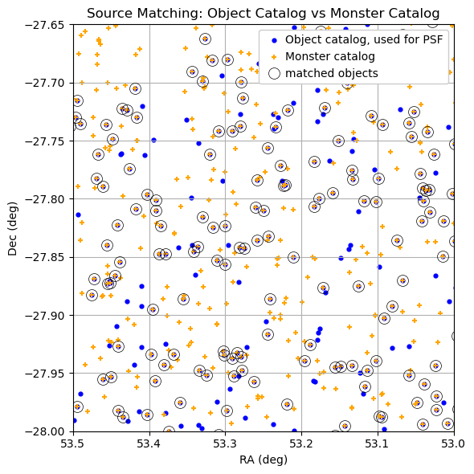

```python
plt.figure(figsize=(6, 6))
plt.scatter(psf_used_table['coord_ra'], psf_used_table['coord_dec'],
            s=12, color='blue', alpha=1.0,
            label='Object catalog, used for PSF')
plt.scatter(coord_ra.to(u.deg), coord_dec.to(u.deg),
            s=22, color='orange', marker='+',
            alpha=1.0, label='Monster catalog')
plt.plot(psf_used_table['coord_ra'][matched],
         psf_used_table['coord_dec'][matched],
         'o', ms=10, mec='black', mew=0.5, color='None',
         label='matched objects')
plt.xlabel('RA (deg)')
plt.ylabel('Dec (deg)')
plt.ylim([-28, -27.65])
plt.xlim([53, 53.5])
plt.title('Source Matching: Object Catalog vs Monster Catalog')
plt.legend(loc='upper right', framealpha=1, handletextpad=0)
plt.gca().invert_xaxis()
plt.grid(True)
plt.tight_layout()
plt.show()
```

> **Figure 1**: RA vs. Dec for objects that were used to estimate the PSF (i.e., bright, isolated stars; blue circles) and objects from the Monster reference catalog (orange crosses). Matches within 1" are circled.

### 3.1. Astrometric residuals

Calculate and visualize residuals.

Compute residuals.

```python
residuals_ra = source_coords[matched].ra - monster_coords[idx][matched].ra
residuals_dec = source_coords[matched].dec - monster_coords[idx][matched].dec
```

Extract sky positions.

```python
ra = source_coords[matched].ra.deg
dec = source_coords[matched].dec.deg
```

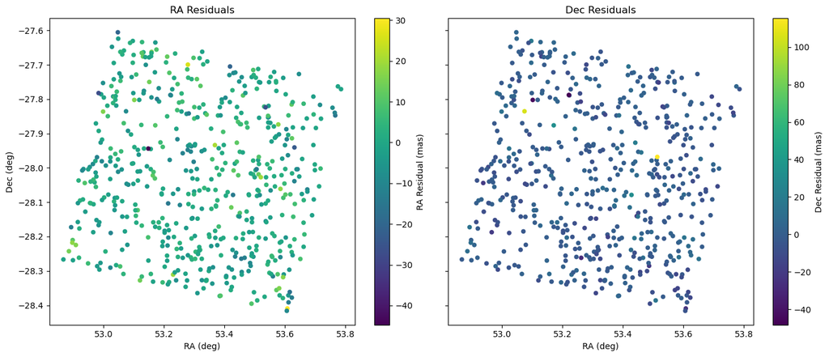

```python
fig, (ax1, ax2) = plt.subplots(1, 2, figsize=(14, 6),
                               sharex=True, sharey=True)

sc1 = ax1.scatter(ra, dec, c=residuals_ra.to('mas').value,
                  s=20)
cb1 = fig.colorbar(sc1, ax=ax1, label='RA Residual (mas)')
ax1.set_title("RA Residuals")
ax1.set_xlabel("RA (deg)")
ax1.set_ylabel("Dec (deg)")
ax1.invert_xaxis()

sc2 = ax2.scatter(ra, dec, c=residuals_dec.to('mas').value,
                  s=20)
cb2 = fig.colorbar(sc2, ax=ax2, label='Dec Residual (mas)')
ax2.set_title("Dec Residuals")
ax2.set_xlabel("RA (deg)")
ax2.invert_xaxis()

plt.tight_layout()
plt.show()
```

> **Figure 2:** Astrometric residuals in RA (left) and Dec (right) across this particular field.